# Real-world Data Wrangling

```python
!python -m pip install kaggle==1.6.12
```

```python
!pip install --target=/workspace ucimlrepo
```

[output not shown]

[output not shown]

## 1. Gather data

## Project Idea:

### E-commerce Web Traffic and User Behavior Analysis

### **1.1.** Problem Statement

In this project, we aim to analyze the e-commerce web traffic and user behavior over a span of five years from 2019 to 2023. The goal is to identify trends, patterns, and anomalies that can help in understanding user engagement, peak traffic periods, and the impact of specific marketing campaigns. The datasets chosen will provide insights into the number of visitors, page views, session durations, and user demographics.

#### **Dataset 1**

###### Method:

Download data manually from kaggle.com

###### Description:

It contains detailed web traffic data, including variables.

###### Dataset variables:

Date, Visits, Visitors, Page_Views, Sessions, Pages_per_Session, Session_Duration, Bounces, and Exits.

###### Why Chosen:

This dataset was chosen because it provides comprehensive web traffic data over multiple years, which is crucial for understanding trends and user behavior over time.

```python
import pandas as pd

ds1 = pd.read_csv('download.csv')
ds1
```

|  | Date | Visits | Visitors | Page_Views | Sessions | Pages_per_Session | Session_Duration | Bounces | Exits |
| --- | --- | --- | --- | --- | --- | --- | --- | --- | --- |
| 0 | 1/1/2019 | 8270 | 80d2a8d1126cbc111503038244fe2ec7 | 10579 | 7336 | 1.44 | 236.29 | 3462 | 1158 |
| 1 | 1/2/2019 | 1860 | 7f1c9f60a743dfe4ed3baf02c45a3a21 | 4553 | 1950 | 2.33 | 150.72 | 700 | 1328 |
| 2 | 1/3/2019 | 6390 | aeecd31f12681394abee7a47f4e46501 | 15124 | 5234 | 2.89 | 276.75 | 1263 | 1729 |
| 3 | 1/4/2019 | 6191 | fc729071f270201018c403633c4967de | 10008 | 6150 | 1.63 | 212.30 | 1911 | 2160 |
| 4 | 1/5/2019 | 6734 | e1acc3379cd0498252ec5871c07daa85 | 16339 | 5426 | 3.01 | 137.19 | 2260 | 4582 |
| ... | ... | ... | ... | ... | ... | ... | ... | ... | ... |
| 1091 | 12/27/2021 | 3969 | 3d604c0c8050924b5208b254e4ef4212 | 10415 | 3987 | 2.61 | 113.26 | 1689 | 1060 |
| 1092 | 12/28/2021 | 4028 | 81de1ebaace367120d05d44a796b897f | 9193 | 4522 | 2.03 | 173.36 | 1182 | 2346 |
| 1093 | 12/29/2021 | 8643 | 90419e3ff324e0105b18bb6437f47095 | 15648 | 7086 | 2.21 | 180.54 | 2040 | 3601 |
| 1094 | 12/30/2021 | 3681 | f9eaea89fb7866f27ce21d3bf7197c3f | 8025 | 3833 | 2.09 | 100.27 | 1164 | 1143 |
| 1095 | 12/31/2021 | 4629 | 76f9ed8b7ad1fba5b08a2c235aa4bffa | 5896 | 5197 | 1.13 | 199.42 | 2203 | 1031 |

1096 rows × 9 columns

#### Dataset 2

###### Method:

Extract data from local SQL database

###### Description:

The second dataset is extracted from local SQL database containing web traffic data for the years 2022 and 2023.

###### Dataset variables:

Date, Visits, Visitors, Page_Views, Sessions, Pages_per_Session, Session_Duration, Bounces, and Exits.

###### Why Chosen:

This dataset was selected because it provides recent web traffic data that complements the first dataset, enabling a comprehensive analysis of user behavior and trends over the full five-year period.

```python
!pip install pymysql
```

```python
import pymysql
```

```python
# Database connection parameters
host = '127.0.0.1'
user = 'root'
database = 'eco'
table = 'for_sql'
```

```python
# Establish a connection to the database
connection = pymysql.connect(
    host=host,
    user=user,
    database=database
)

try:
    # Create a cursor object to interact with the database
    cursor = connection.cursor()

    # Write the SQL query to fetch data from the specified table
    query = f"SELECT * FROM {table}"

    # Execute the SQL query
    cursor.execute(query)

    # Fetch all the rows from the executed query
    rows = cursor.fetchall()

    # Retrieve column names from the cursor description
    column_names = [desc[0] for desc in cursor.description]

    # Create a DataFrame from the fetched data
    ds2 = pd.DataFrame(rows, columns=column_names)

    # Print the first few rows of the DataFrame to verify the data
    print(ds2.head())

    # Specify the path for the CSV file
    csv_file_path = 'extracted_data.csv'

    # Save the DataFrame to a CSV file
    ds2.to_csv(csv_file_path, index=False)
    print(f"Data has been saved to {csv_file_path}")

finally:
    # Ensure the database connection is closed
    connection.close()
```

```
       Date  Visits                          Visitors  Page_Views  Sessions  \
0  1/1/2022    5225  3f448966317dfc7a4280f30a79508dc0       13275      4507
1  1/2/2022    4067  f075861b879a4fff877be064cf5298ac        8145      3278
2  1/3/2022    6941  d9c4715dc014e80e13fcceb78d63a646        8579      6421
3  1/4/2022    2386  fa0426c33aa3669d8c36c57d9116b5a0        3131      2470
4  1/5/2022    3866  215f52e0a6b5c4cd47424ebee6dcf82f        7335      3306

   Pages_per_Session  Session_Duration  Bounces  Exits
0               2.94            250.56     2046   1348
1               2.48            264.65     1025   1944
2               1.34            275.88     1855   1411
3               1.27            197.54     1153    671
4               2.22            226.13     1652   2137
Data has been saved to extracted_data.csv
```

```python
# Combine the datasets on the Date column
combined_data = pd.concat([ds1, ds2])

# Ensure the Date column is in datetime format
combined_data['Date'] = pd.to_datetime(combined_data['Date'])

# Sort the data by Date
combined_data = combined_data.sort_values(by='Date')

# Display the combined data
combined_data.head()
```

|  | Date | Visits | Visitors | Page_Views | Sessions | Pages_per_Session | Session_Duration | Bounces | Exits |
| --- | --- | --- | --- | --- | --- | --- | --- | --- | --- |
| 0 | 2019-01-01 | 8270 | 80d2a8d1126cbc111503038244fe2ec7 | 10579 | 7336 | 1.44 | 236.29 | 3462 | 1158 |
| 1 | 2019-01-02 | 1860 | 7f1c9f60a743dfe4ed3baf02c45a3a21 | 4553 | 1950 | 2.33 | 150.72 | 700 | 1328 |
| 2 | 2019-01-03 | 6390 | aeecd31f12681394abee7a47f4e46501 | 15124 | 5234 | 2.89 | 276.75 | 1263 | 1729 |
| 3 | 2019-01-04 | 6191 | fc729071f270201018c403633c4967de | 10008 | 6150 | 1.63 | 212.30 | 1911 | 2160 |
| 4 | 2019-01-05 | 6734 | e1acc3379cd0498252ec5871c07daa85 | 16339 | 5426 | 3.01 | 137.19 | 2260 | 4582 |

```python
# Save the combined dataset to a CSV file
combined_data.to_csv('combined_ecommerce_data.csv', index=False)
```

## 2. Assess data

### Quality Issue :

```python
# Check for inconsistencies in the dataset
combined_data.describe()
```

|  | Date | Visits | Page_Views | Sessions | Pages_per_Session | Session_Duration | Bounces | Exits |
| --- | --- | --- | --- | --- | --- | --- | --- | --- |
| count | 1826 | 1826.000000 | 1826.000000 | 1826.000000 | 1826.000000 | 1826.000000 | 1826.000000 | 1826.000000 |
| mean | 2021-07-01 12:00:00 | 5519.886637 | 11458.601862 | 5515.450712 | 2.113456 | 201.665947 | 1916.819277 | 2298.897043 |
| min | 2019-01-01 00:00:00 | 1001.000000 | 1387.000000 | 805.000000 | 1.010000 | 100.270000 | 191.000000 | 195.000000 |
| 25% | 2020-04-01 06:00:00 | 3297.250000 | 6320.500000 | 3209.000000 | 1.620000 | 153.135000 | 1082.000000 | 1154.000000 |
| 50% | 2021-07-01 12:00:00 | 5560.500000 | 10767.500000 | 5531.000000 | 2.070000 | 202.520000 | 1786.000000 | 2004.500000 |
| 75% | 2022-09-30 18:00:00 | 7796.000000 | 15508.500000 | 7643.250000 | 2.540000 | 252.357500 | 2589.500000 | 3169.500000 |
| max | 2023-12-31 00:00:00 | 9996.000000 | 29145.000000 | 11872.000000 | 3.690000 | 299.950000 | 5634.000000 | 7885.000000 |
| std | NaN | 2576.955538 | 6213.833794 | 2677.440539 | 0.593298 | 57.585689 | 1066.917196 | 1454.255969 |

Issue and justification: There appear to be significant variations in the dataset, which could indicate the presence of outliers.

### Tidiness Issue :

Ensure each variable is a column, each observation is a row, and each type of observational unit forms a table. Address issues where variables might be stored in one column or spread across multiple columns

```python
# Check column names and data structure
print(combined_data.columns)
print(combined_data.info())
print(combined_data.describe())
combined_data.head
```

```
Index(['Date', 'Visits', 'Visitors', 'Page_Views', 'Sessions',
       'Pages_per_Session', 'Session_Duration', 'Bounces', 'Exits'],
      dtype='object')
<class 'pandas.core.frame.DataFrame'>
Index: 1826 entries, 0 to 729
Data columns (total 9 columns):
 #   Column             Non-Null Count  Dtype
---  ------             --------------  -----
 0   Date               1826 non-null   datetime64[ns]
 1   Visits             1826 non-null   int64
 2   Visitors           1826 non-null   object
 3   Page_Views         1826 non-null   int64
 4   Sessions           1826 non-null   int64
 5   Pages_per_Session  1826 non-null   float64
 6   Session_Duration   1826 non-null   float64
 7   Bounces            1826 non-null   int64
 8   Exits              1826 non-null   int64
dtypes: datetime64[ns](1), float64(2), int64(5), object(1)
memory usage: 142.7+ KB
None
                      Date       Visits    Page_Views      Sessions  \
count                 1826  1826.000000   1826.000000   1826.000000
mean   2021-07-01 12:00:00  5519.886637  11458.601862   5515.450712
min    2019-01-01 00:00:00  1001.000000   1387.000000    805.000000
25%    2020-04-01 06:00:00  3297.250000   6320.500000   3209.000000
50%    2021-07-01 12:00:00  5560.500000  10767.500000   5531.000000
75%    2022-09-30 18:00:00  7796.000000  15508.500000   7643.250000
max    2023-12-31 00:00:00  9996.000000  29145.000000  11872.000000
std                    NaN  2576.955538   6213.833794   2677.440539

       Pages_per_Session  Session_Duration      Bounces        Exits
count        1826.000000       1826.000000  1826.000000  1826.000000
mean            2.113456        201.665947  1916.819277  2298.897043
min             1.010000        100.270000   191.000000   195.000000
25%             1.620000        153.135000  1082.000000  1154.000000
50%             2.070000        202.520000  1786.000000  2004.500000
75%             2.540000        252.357500  2589.500000  3169.500000
max             3.690000        299.950000  5634.000000  7885.000000
std             0.593298         57.585689  1066.917196  1454.255969
```

```
<bound method NDFrame.head of           Date  Visits                          Visitors  Page_Views  \
0   2019-01-01    8270  80d2a8d1126cbc111503038244fe2ec7       10579
1   2019-01-02    1860  7f1c9f60a743dfe4ed3baf02c45a3a21        4553
2   2019-01-03    6390  aeecd31f12681394abee7a47f4e46501       15124
3   2019-01-04    6191  fc729071f270201018c403633c4967de       10008
4   2019-01-05    6734  e1acc3379cd0498252ec5871c07daa85       16339
..         ...     ...                               ...         ...
725 2023-12-27    2012  4803736bc753788b0eaa3b0c366b88ca        2533
726 2023-12-28    3785  28e8a401ad7337b2bd47908b998125be       11041
727 2023-12-29    4725  f408031d9c0370f017f5537ce23dfdde        7455
728 2023-12-30    5576  c98ffe8ea8f768e0f99ef3b2e89806fa       14609
729 2023-12-31    6782  7b2d414f0edc509299965bdbdb710a92       17594

     Sessions  Pages_per_Session  Session_Duration  Bounces  Exits
0        7336               1.44            236.29     3462   1158
1        1950               2.33            150.72      700   1328
2        5234               2.89            276.75     1263   1729
3        6150               1.63            212.30     1911   2160
4        5426               3.01            137.19     2260   4582
..        ...                ...               ...      ...    ...
725      2017               1.26            268.72      665    402
726      4498               2.45            135.65     1223   3138
727      4302               1.73            280.92     1662   1001
728      6228               2.35            168.13     1579   1651
729      6036               2.91            175.42     2578   3320

[1826 rows x 9 columns]>
```

#### Issue and justification:

Tidying data maintains integrity, aiding analysis and visualization. It ensures structured data for clear manipulation and interpretation.

## 3. Clean data

### **Quality Issue 1 : Data Consistency**

#### Action:

Identify and handle outliers in the dataset by examining values beyond typical ranges.

```python
# Assuming combined_data is the DataFrame containing the data
# Select only numeric columns for outlier detection
numeric_cols = combined_data.select_dtypes(include='number')

# Detecting outliers using the IQR method
Q1 = numeric_cols.quantile(0.25)
Q3 = numeric_cols.quantile(0.75)
IQR = Q3 - Q1

# Filtering outliers
outliers = numeric_cols[~((numeric_cols < (Q1 - 1.5 * IQR)) | (numeric_cols > (Q3 + 1.5 * IQR))).any(axis=1)]

# Reset the index of outliers and original DataFrame to align them correctly
outliers = outliers.reset_index(drop=True)
combined_data_filtered = combined_data.reset_index(drop=True)

# Combine filtered numeric data with non-numeric columns
filtered_data = pd.concat([combined_data_filtered[['Date']], outliers], axis=1).dropna()

# Summary statistics after outlier removal
summary_after_outliers = filtered_data.describe()

summary_after_outliers
```

|  | Date | Visits | Page_Views | Sessions | Pages_per_Session | Session_Duration | Bounces | Exits |
| --- | --- | --- | --- | --- | --- | --- | --- | --- |
| count | 1786 | 1786.000000 | 1786.000000 | 1786.000000 | 1786.000000 | 1786.000000 | 1786.000000 | 1786.000000 |
| mean | 2021-06-11 12:00:00 | 5435.538074 | 11218.301232 | 5422.734043 | 2.107486 | 201.768208 | 1876.488242 | 2228.311310 |
| min | 2019-01-01 00:00:00 | 1001.000000 | 1387.000000 | 805.000000 | 1.010000 | 100.270000 | 191.000000 | 195.000000 |
| 25% | 2020-03-22 06:00:00 | 3200.750000 | 6243.250000 | 3158.250000 | 1.620000 | 153.075000 | 1071.000000 | 1137.500000 |
| 50% | 2021-06-11 12:00:00 | 5471.500000 | 10583.500000 | 5425.000000 | 2.060000 | 202.600000 | 1758.000000 | 1982.000000 |
| 75% | 2022-08-31 18:00:00 | 7654.250000 | 15256.250000 | 7498.750000 | 2.530000 | 252.577500 | 2572.250000 | 3102.750000 |
| max | 2023-11-21 00:00:00 | 9996.000000 | 29145.000000 | 11752.000000 | 3.690000 | 299.950000 | 4797.000000 | 6172.000000 |
| std | NaN | 2540.705386 | 6029.310205 | 2625.472453 | 0.589182 | 57.725134 | 1023.232493 | 1358.611251 |

### Justification:

##### Reduced Count:

###### Mean Values:

The mean values have slightly decreased, indicating a reduction in the influence of extreme values on the dataset.

##### Standard Deviation:

The standard deviation has decreased, showing less dispersion and suggesting a more consistent dataset.

### Quality Issue 2 : Inconsistent Data

#### Action:

Data that is inconsistent in format, units, or naming conventions

```python
# Ensure the 'Date' column is in datetime format
combined_data['Date'] = pd.to_datetime(combined_data['Date'], errors='coerce')

# Display the first few rows to verify the format
print(combined_data['Date'].head())

# Drop rows where the 'Date' conversion resulted in NaT (Not a Time)
combined_data = combined_data.dropna(subset=['Date'])

# Verify the change
print(combined_data.info())
```

```
0   2019-01-01
1   2019-01-02
2   2019-01-03
3   2019-01-04
4   2019-01-05
Name: Date, dtype: datetime64[ns]
<class 'pandas.core.frame.DataFrame'>
Index: 1826 entries, 0 to 729
Data columns (total 9 columns):
 #   Column             Non-Null Count  Dtype
---  ------             --------------  -----
 0   Date               1826 non-null   datetime64[ns]
 1   Visits             1826 non-null   int64
 2   Visitors           1826 non-null   object
 3   Page_Views         1826 non-null   int64
 4   Sessions           1826 non-null   int64
 5   Pages_per_Session  1826 non-null   float64
 6   Session_Duration   1826 non-null   float64
 7   Bounces            1826 non-null   int64
 8   Exits              1826 non-null   int64
dtypes: datetime64[ns](1), float64(2), int64(5), object(1)
memory usage: 142.7+ KB
None
```

### Justification:

##### Standardizing Date Formats:

Ensures uniformity across the dataset, mitigating errors in date-based operations and ensuring consistency in temporal analysis

### **Tidiness Issue 1 :Columns Containing Multiple Variables**

#### Action:

Data where one column contains multiple variables

```python
# Assume 'Session_Info' is in the format "session_duration|pages_per_session"
if 'Session_Info' in combined_data.columns:
    combined_data[['Session_Duration', 'Pages_per_Session']] = combined_data['Session_Info'].str.split('|', expand=True)

    # Convert the new columns to appropriate data types
    combined_data['Session_Duration'] = pd.to_numeric(combined_data['Session_Duration'], errors='coerce')
    combined_data['Pages_per_Session'] = pd.to_numeric(combined_data['Pages_per_Session'], errors='coerce')

    # Drop the original 'Session_Info' column
    combined_data = combined_data.drop(columns=['Session_Info'])

# Display the first few rows to verify the separation
print(combined_data.head())
```

```
        Date  Visits                          Visitors  Page_Views  Sessions  \
0 2019-01-01    8270  80d2a8d1126cbc111503038244fe2ec7       10579      7336
1 2019-01-02    1860  7f1c9f60a743dfe4ed3baf02c45a3a21        4553      1950
2 2019-01-03    6390  aeecd31f12681394abee7a47f4e46501       15124      5234
3 2019-01-04    6191  fc729071f270201018c403633c4967de       10008      6150
4 2019-01-05    6734  e1acc3379cd0498252ec5871c07daa85       16339      5426

   Pages_per_Session  Session_Duration  Bounces  Exits
0               1.44            236.29     3462   1158
1               2.33            150.72      700   1328
2               2.89            276.75     1263   1729
3               1.63            212.30     1911   2160
4               3.01            137.19     2260   4582
```

### Justification:

##### Separating Multi-Variable Columns:

Enhances data clarity and query efficiency, facilitating more straightforward data exploration and analysis

### Tidiness Issue 2 : Multiple Observational Units in a Single Table

#### Action:

Split the dataset into two separate tables if necessary.

```python
# Print out the column names to verify
print(combined_data.columns)

# Adjust column selections based on actual column names in your DataFrame
web_traffic_df = combined_data[['Date', 'Visits', 'Page_Views', 'Sessions', 'Pages_per_Session', 'Session_Duration', 'Bounces', 'Exits']]

# Assuming correct column names based on your dataset
user_demographics_df = combined_data[['Visitors']]

# Display the first few rows to verify
print("Web Traffic DataFrame:")
print(web_traffic_df.head())

print("\nUser Demographics DataFrame:")
print(user_demographics_df.head())
```

```
Index(['Date', 'Visits', 'Visitors', 'Page_Views', 'Sessions',
       'Pages_per_Session', 'Session_Duration', 'Bounces', 'Exits'],
      dtype='object')
Web Traffic DataFrame:
        Date  Visits  Page_Views  Sessions  Pages_per_Session  \
0 2019-01-01    8270       10579      7336               1.44
1 2019-01-02    1860        4553      1950               2.33
2 2019-01-03    6390       15124      5234               2.89
3 2019-01-04    6191       10008      6150               1.63
4 2019-01-05    6734       16339      5426               3.01

   Session_Duration  Bounces  Exits
0            236.29     3462   1158
1            150.72      700   1328
2            276.75     1263   1729
3            212.30     1911   2160
4            137.19     2260   4582

User Demographics DataFrame:
                           Visitors
0  80d2a8d1126cbc111503038244fe2ec7
1  7f1c9f60a743dfe4ed3baf02c45a3a21
2  aeecd31f12681394abee7a47f4e46501
3  fc729071f270201018c403633c4967de
4  e1acc3379cd0498252ec5871c07daa85
```

### Justification:

##### Splitting the Dataset into Separate Tables:

Improves organizational clarity and analytical focus, optimizing data management and insights generation

### **Remove unnecessary variables and combine datasets**

Depending on the datasets, you can also peform the combination before the cleaning steps.

```python
# Selecting necessary columns
cleaned_data = combined_data[['Date', 'Visits', 'Page_Views', 'Sessions', 'Session_Duration']]
cleaned_data.head()
```

|  | Date | Visits | Page_Views | Sessions | Session_Duration |
| --- | --- | --- | --- | --- | --- |
| 0 | 2019-01-01 | 8270 | 10579 | 7336 | 236.29 |
| 1 | 2019-01-02 | 1860 | 4553 | 1950 | 150.72 |
| 2 | 2019-01-03 | 6390 | 15124 | 5234 | 276.75 |
| 3 | 2019-01-04 | 6191 | 10008 | 6150 | 212.30 |
| 4 | 2019-01-05 | 6734 | 16339 | 5426 | 137.19 |

## 4. Update your data store

#### Action:

Save the cleaned data and maintain different versions for raw and cleaned data

```python
# Saving the cleaned dataset
cleaned_data.to_csv('cleaned_ecommerce_data.csv', index=False)
```

## 5. Answer the research question

### **5.1:** Research Question: What are the trends and patterns in e-commerce web traffic and user behavior from 2019 to 2023?

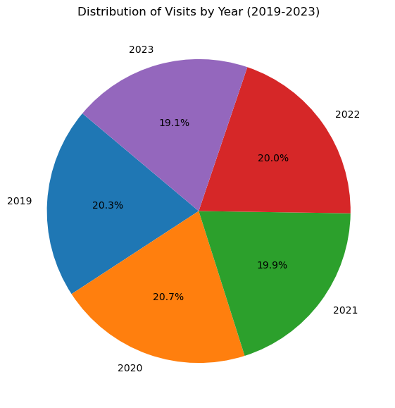

```python
import matplotlib.pyplot as plt

# Assuming cleaned_data is a DataFrame with 'Date' and 'Visits' columns
# Extract year from the Date using .loc to avoid the SettingWithCopyWarning
cleaned_data.loc[:, 'Year'] = cleaned_data['Date'].dt.year

# Aggregate visits by year
yearly_visits = cleaned_data.groupby('Year')['Visits'].sum()

# Plot pie chart
plt.figure(figsize=(10, 7))
plt.pie(yearly_visits, labels=yearly_visits.index, autopct='%1.1f%%', startangle=140)
plt.title('Distribution of Visits by Year (2019-2023)')
plt.show()
```

#### Visual 2: Average Session Duration Over Time

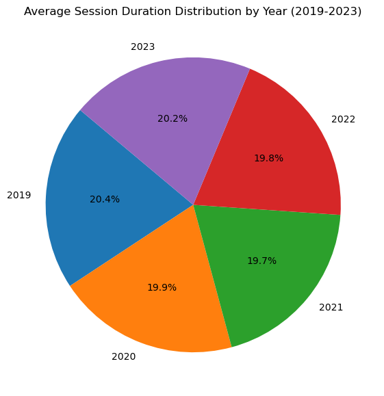

```python
# Assuming cleaned_data is a DataFrame with 'Date' and 'Session_Duration' columns
# Extract year from the Date using .loc to avoid the SettingWithCopyWarning
cleaned_data.loc[:, 'Year'] = cleaned_data['Date'].dt.year

# Aggregate average session duration by year
yearly_avg_duration = cleaned_data.groupby('Year')['Session_Duration'].mean()

# Plot pie chart
plt.figure(figsize=(10, 7))
plt.pie(yearly_avg_duration, labels=yearly_avg_duration.index, autopct='%1.1f%%', startangle=140)
plt.title('Average Session Duration Distribution by Year (2019-2023)')
plt.show()
```

### **5.2:** Reflection

#### Answer:

If I had more time to complete the project, I would further investigate additional data quality issues such as ensuring the accuracy of the Visitors data and exploring more sophisticated methods for outlier detection. I would also look into other variables that could impact user behavior, such as marketing campaign data, and explore more advanced analytical techniques to provide deeper insights into user engagement and trends.